# Chapter4: Clustering and classification

```r
cor_matrix <- cor(Boston)
cor_matrix
```

```
##                crim          zn       indus         chas         nox
## crim     1.00000000 -0.20046922  0.40658341 -0.055891582  0.42097171
## zn      -0.20046922  1.00000000 -0.53382819 -0.042696719 -0.51660371
## indus    0.40658341 -0.53382819  1.00000000  0.062938027  0.76365145
## chas    -0.05589158 -0.04269672  0.06293803  1.000000000  0.09120281
## nox      0.42097171 -0.51660371  0.76365145  0.091202807  1.00000000
## rm      -0.21924670  0.31199059 -0.39167585  0.091251225 -0.30218819
## age      0.35273425 -0.56953734  0.64477851  0.086517774  0.73147010
## dis     -0.37967009  0.66440822 -0.70802699 -0.099175780 -0.76923011
## rad      0.62550515 -0.31194783  0.59512927 -0.007368241  0.61144056
## tax      0.58276431 -0.31456332  0.72076018 -0.035586518  0.66802320
## ptratio  0.28994558 -0.39167855  0.38324756 -0.121515174  0.18893268
## black   -0.38506394  0.17552032 -0.35697654  0.048788485 -0.38005064
## lstat    0.45562148 -0.41299457  0.60379972 -0.053929298  0.59087892
## medv    -0.38830461  0.36044534 -0.48372516  0.175260177 -0.42732077
##                  rm         age         dis          rad         tax
## crim    -0.21924670  0.35273425 -0.37967009  0.625505145  0.58276431
## zn       0.31199059 -0.56953734  0.66440822 -0.311947826 -0.31456332
## indus   -0.39167585  0.64477851 -0.70802699  0.595129275  0.72076018
## chas     0.09125123  0.08651777 -0.09917578 -0.007368241 -0.03558652
## nox     -0.30218819  0.73147010 -0.76923011  0.611440563  0.66802320
## rm       1.00000000 -0.24026493  0.20524621 -0.209846668 -0.29204783
## age     -0.24026493  1.00000000 -0.74788054  0.456022452  0.50645559
## dis      0.20524621 -0.74788054  1.00000000 -0.494587930 -0.53443158
## rad     -0.20984667  0.45602245 -0.49458793  1.000000000  0.91022819
## tax     -0.29204783  0.50645559 -0.53443158  0.910228189  1.00000000
## ptratio -0.35550149  0.26151501 -0.23247054  0.464741179  0.46085304
## black    0.12806864 -0.27353398  0.29151167 -0.444412816 -0.44180801
## lstat   -0.61380827  0.60233853 -0.49699583  0.488676335  0.54399341
## medv     0.69535995 -0.37695457  0.24992873 -0.381626231 -0.46853593
##            ptratio       black      lstat       medv
## crim     0.2899456 -0.38506394  0.4556215 -0.3883046
## zn      -0.3916785  0.17552032 -0.4129946  0.3604453
## indus    0.3832476 -0.35697654  0.6037997 -0.4837252
## chas    -0.1215152  0.04878848 -0.0539293  0.1752602
## nox      0.1889327 -0.38005064  0.5908789 -0.4273208
## rm      -0.3555015  0.12806864 -0.6138083  0.6953599
## age      0.2615150 -0.27353398  0.6023385 -0.3769546
## dis     -0.2324705  0.29151167 -0.4969958  0.2499287
## rad      0.4647412 -0.44441282  0.4886763 -0.3816262
## tax      0.4608530 -0.44180801  0.5439934 -0.4685359
## ptratio  1.0000000 -0.17738330  0.3740443 -0.5077867
## black   -0.1773833  1.00000000 -0.3660869  0.3334608
## lstat    0.3740443 -0.36608690  1.0000000 -0.7376627
## medv    -0.5077867  0.33346082 -0.7376627  1.0000000
```

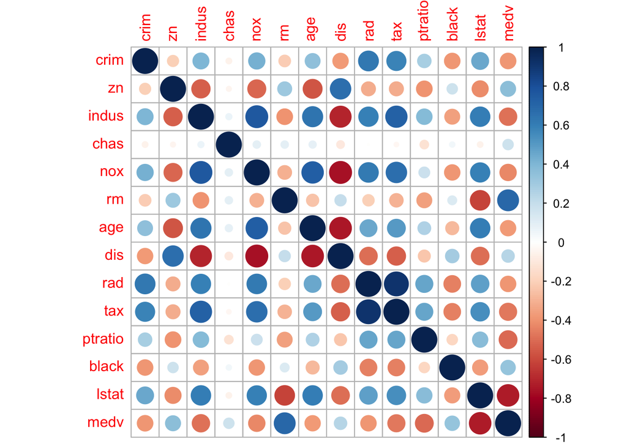

```r
library(corrplot)
corrplot(cor_matrix)
```

## 4. Scaling data and dividing data to training/testing sets

Let’s scale the dataset and convert it to data frame class. As we can see from the summary-information, the data variables changed due to scaling process.

```r
Boston_scaled <- scale(Boston)
summary(Boston_scaled)
```

```
##       crim                 zn               indus
##  Min.   :-0.419367   Min.   :-0.48724   Min.   :-1.5563
##  1st Qu.:-0.410563   1st Qu.:-0.48724   1st Qu.:-0.8668
##  Median :-0.390280   Median :-0.48724   Median :-0.2109
##  Mean   : 0.000000   Mean   : 0.00000   Mean   : 0.0000
##  3rd Qu.: 0.007389   3rd Qu.: 0.04872   3rd Qu.: 1.0150
##  Max.   : 9.924110   Max.   : 3.80047   Max.   : 2.4202
##       chas              nox                rm               age
##  Min.   :-0.2723   Min.   :-1.4644   Min.   :-3.8764   Min.   :-2.3331
##  1st Qu.:-0.2723   1st Qu.:-0.9121   1st Qu.:-0.5681   1st Qu.:-0.8366
##  Median :-0.2723   Median :-0.1441   Median :-0.1084   Median : 0.3171
##  Mean   : 0.0000   Mean   : 0.0000   Mean   : 0.0000   Mean   : 0.0000
##  3rd Qu.:-0.2723   3rd Qu.: 0.5981   3rd Qu.: 0.4823   3rd Qu.: 0.9059
##  Max.   : 3.6648   Max.   : 2.7296   Max.   : 3.5515   Max.   : 1.1164
##       dis               rad               tax             ptratio
##  Min.   :-1.2658   Min.   :-0.9819   Min.   :-1.3127   Min.   :-2.7047
##  1st Qu.:-0.8049   1st Qu.:-0.6373   1st Qu.:-0.7668   1st Qu.:-0.4876
##  Median :-0.2790   Median :-0.5225   Median :-0.4642   Median : 0.2746
##  Mean   : 0.0000   Mean   : 0.0000   Mean   : 0.0000   Mean   : 0.0000
##  3rd Qu.: 0.6617   3rd Qu.: 1.6596   3rd Qu.: 1.5294   3rd Qu.: 0.8058
##  Max.   : 3.9566   Max.   : 1.6596   Max.   : 1.7964   Max.   : 1.6372
##      black             lstat              medv
##  Min.   :-3.9033   Min.   :-1.5296   Min.   :-1.9063
##  1st Qu.: 0.2049   1st Qu.:-0.7986   1st Qu.:-0.5989
##  Median : 0.3808   Median :-0.1811   Median :-0.1449
##  Mean   : 0.0000   Mean   : 0.0000   Mean   : 0.0000
##  3rd Qu.: 0.4332   3rd Qu.: 0.6024   3rd Qu.: 0.2683
##  Max.   : 0.4406   Max.   : 3.5453   Max.   : 2.9865
```

```r
class(Boston_scaled)
```

```
## [1] "matrix"
```

```r
Boston_scaled2 <- as.data.frame(Boston_scaled)
```

```r
summary(Boston_scaled2$crim)
```

```
##      Min.   1st Qu.    Median      Mean   3rd Qu.      Max.
## -0.419367 -0.410563 -0.390280  0.000000  0.007389  9.924110
```

```r
quantile_vector <- quantile(Boston_scaled2$crim)
quantile_vector
```

```
##           0%          25%          50%          75%         100%
## -0.419366929 -0.410563278 -0.390280295  0.007389247  9.924109610
```

```r
crime <- cut(Boston_scaled2$crim, breaks = quantile_vector, include.lowest = TRUE)

library(dplyr)
Boston_scaled2 <- dplyr::select(Boston_scaled2, -crim)
Boston_scaled2 <- data.frame(Boston_scaled2, crime)
```

Now the old crim variable is removed and a new scaled crime variable has been added.

Let’s divide the data to training set (80 % of the data) and testing set (20 % of the data).

```r
n <- nrow(Boston_scaled2)
ind <- sample(n, size = n * 0.8)
train <- Boston_scaled2 [ind,]
test <- Boston_scaled2 [-ind,]
```

## 5. Linear discriminant analysis

Next I will use linear discriminant analysis for classification. Analysis is used to find the combination of the variables that seperates the target variable classes. For this case the target variable is the crime variable and the predictor variables are all the other variables.

```r
lda.fit <- lda(crime ~ ., data=train)
lda.fit
```

```
## Call:
## lda(crime ~ ., data = train)
##
## Prior probabilities of groups:
## [-0.419,-0.411]  (-0.411,-0.39] (-0.39,0.00739]  (0.00739,9.92]
##       0.2599010       0.2524752       0.2475248       0.2400990
##
## Group means:
##                          zn      indus        chas        nox          rm
## [-0.419,-0.411]  1.05613255 -0.9181282 -0.12234430 -0.9008910  0.44391024
## (-0.411,-0.39]  -0.04312553 -0.2936615 -0.04073494 -0.5729500 -0.09670717
## (-0.39,0.00739] -0.37404455  0.2058234  0.27886497  0.3901091  0.18211285
## (0.00739,9.92]  -0.48724019  1.0172187  0.01179157  1.1035970 -0.42519286
##                        age        dis        rad        tax    ptratio
## [-0.419,-0.411] -0.9667530  0.8946332 -0.6712382 -0.7120038 -0.4871167
## (-0.411,-0.39]  -0.4088348  0.3988871 -0.5483812 -0.4636315 -0.1329763
## (-0.39,0.00739]  0.3911383 -0.4055751 -0.4018954 -0.2967723 -0.3194231
## (0.00739,9.92]   0.7993711 -0.8481691  1.6371072  1.5133254  0.7795879
##                      black       lstat        medv
## [-0.419,-0.411]  0.3822576 -0.78202545  0.52465307
## (-0.411,-0.39]   0.3094507 -0.17972894  0.03320925
## (-0.39,0.00739]  0.1246704 -0.03417745  0.25879817
## (0.00739,9.92]  -0.7941935  0.89301007 -0.66995787
##
## Coefficients of linear discriminants:
##                 LD1         LD2         LD3
## zn       0.10029973  0.66456403 -1.01134751
## indus    0.03819262 -0.28309336  0.27778551
## chas    -0.07328686 -0.03556447  0.05096397
## nox      0.42789178 -0.76548582 -1.29014683
## rm      -0.13240640 -0.11980782 -0.16770826
## age      0.22338538 -0.34871376 -0.06864040
## dis     -0.08739087 -0.26825295  0.35155722
## rad      3.13674628  0.94860517 -0.08855424
## tax     -0.01309089  0.08878674  0.62362007
## ptratio  0.12272758 -0.02187527 -0.31058476
## black   -0.14994118  0.02400064  0.06091028
## lstat    0.23422473 -0.24529404  0.34419604
## medv     0.26585287 -0.47659879 -0.12777289
##
## Proportion of trace:
##    LD1    LD2    LD3
## 0.9424 0.0448 0.0129
```

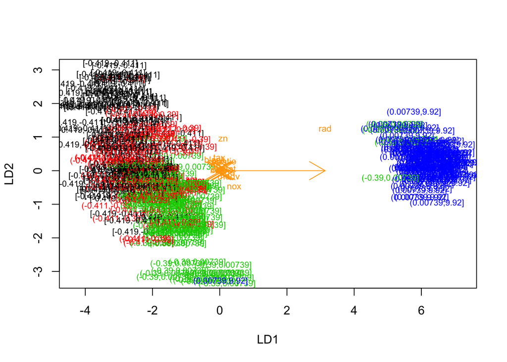

```r
lda.arrows <- function (x, myscale = 1, arrow_heads = 0.1,
color = "orange", tex=0.75, choices = c(1,2)) {
  heads <- coef (x)
  arrows(x0 = 0, y0 = 0,
        x1 = myscale * heads[,choices [1]],
        x2 = myscale * heads[,choices [2]], col=color,
lenght = arrow_heads)
  text(myscale * heads[,choices], labels= row.names(heads),
        cex = tex, col=color, pos=3)
}

classes <- as.numeric(train$crime)

plot(lda.fit, dimen = 2, col = classes, pch = classes)
lda.arrows(lda.fit, myscale = 1)
```

## 6. Predicting classes

First I save the crime categories and remove the crime variable from the test dataset.

```r
crime_categories <- as.numeric(test$crime)

library(dplyr)

test_data <- dplyr::select(test, -crime)
test_data <- data.frame(test_data, crime_categories)
```

Next it’s time to predict the classes on the test data using LDA model.

```r
lda.pred <- predict(lda.fit, newdata = test_data)

table (correct = crime_categories, predicted = lda.pred$class)
```

```
##        predicted
## correct [-0.419,-0.411] (-0.411,-0.39] (-0.39,0.00739] (0.00739,9.92]
##       1               9              9               4              0
##       2               1             18               5              0
##       3               1             10              14              1
##       4               0              0               0             30
```

As can be seen from the table, the classifier predicted crime rates quite well but not perfectly.

## 7. k-means algorithm

Let’s first reload the Boston dataset and standardize it.

```r
library(MASS)
data("Boston")
Boston_stand <- scale(Boston)
```

Now when the data is scaled it’s possible to get comparable distances between observations.

```r
dist <- dist(Boston_stand)
summary(dist)
```

```
##    Min. 1st Qu.  Median    Mean 3rd Qu.    Max.
##  0.1343  3.4625  4.8241  4.9111  6.1863 14.3970
```

```r
dist_manhattan <- dist(Boston_stand, method = 'manhattan')
summary(dist_manhattan)
```

```
##    Min. 1st Qu.  Median    Mean 3rd Qu.    Max.
##  0.2662  8.4832 12.6090 13.5488 17.7568 48.8618
```

K-means is a clustering method and now I’m going to use it to assign observations of scaled Boston data to groups based on similarity.

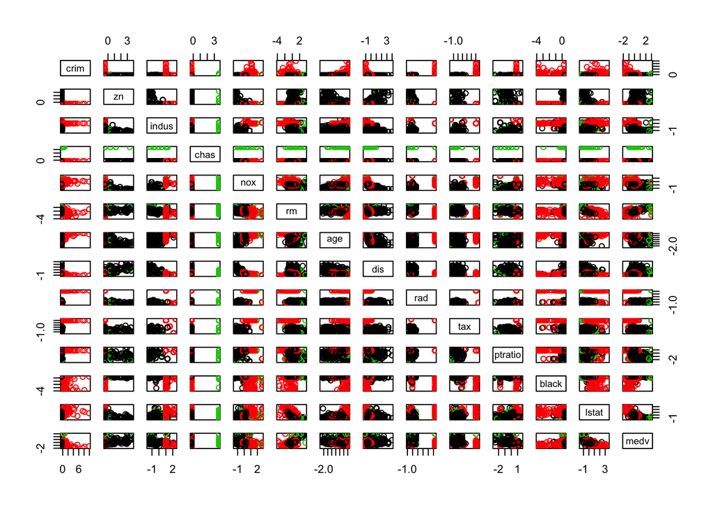

```r
kmeans <- kmeans(Boston_stand, centers = 3)

pairs(Boston_stand, col = kmeans$cluster)
```